# Regressão Linear

Elton J

05/05/2020

# Regressão Linear - Teoria e Aplicação R

- 1. Regressão Linear Ponderada - WLS
- 2. Regressão Linear Simples - OLS
- 3. Regressão Linear Múltipla
- 4. ANOVA de uma Regressão
- 5. ANOVA para modelos aninhados

```r
suppressMessages(library(dplyr))
suppressMessages(library(GLMsData))
suppressMessages(library(ggplot2))
suppressMessages(library(knitr))
suppressMessages(library(kableExtra))
suppressMessages(library(psych))
```

## Regressão Linear Ponderada WLS

### 1.1 Dados

```r
data(gestation)

gestation %>%
  head() %>%
    kable() %>%
      kable_styling()
```

| Age | Births | Weight | SD |
| --- | --- | --- | --- |
| 22 | 1 | 0.520 | NA |
| 23 | 1 | 0.700 | NA |
| 25 | 1 | 1.000 | NA |
| 27 | 1 | 1.170 | NA |
| 28 | 6 | 1.198 | 0.121 |
| 29 | 1 | 1.480 | NA |

```r
describe(gestation) %>%
  round(2) %>%
    kable() %>%
      kable_styling()
```

|  | vars | n | mean | sd | median | trimmed | mad | min | max | range | skew | kurtosis | se |
| --- | --- | --- | --- | --- | --- | --- | --- | --- | --- | --- | --- | --- | --- |
| Age | 1 | 21 | 33.76 | 6.59 | 34.00 | 33.94 | 7.41 | 22.00 | 44.00 | 22.00 | -0.15 | -1.22 | 1.44 |
| Births | 2 | 21 | 72.05 | 123.59 | 7.00 | 44.53 | 8.90 | 1.00 | 401.00 | 400.00 | 1.57 | 1.01 | 26.97 |
| Weight | 3 | 21 | 2.33 | 1.07 | 2.52 | 2.38 | 1.33 | 0.52 | 3.74 | 3.22 | -0.21 | -1.55 | 0.23 |
| SD | 4 | 15 | 0.41 | 0.11 | 0.43 | 0.41 | 0.03 | 0.12 | 0.59 | 0.47 | -0.68 | 0.86 | 0.03 |

### 1.2 Estimação (Na Raça)

#### 1.2.1 Coeficientes ($\beta$’s) e $Var(Y_i / X_i = x)$

$$\hat{\beta_0} = \overline{y}_w - \hat{\beta_1} \overline{x}_w$$

$$\hat{\beta_1} = \frac{SS_{xy}}{SS_{x}} = \frac{\sum_{i=1}^{n}w_i(x_i -
\overline{x}_w)y_i}{\sum_{i=1}^{n}w_i(x_i -
\overline{x}_w)x_i}$$

$$R^2 = 1 - \frac{SQR}{SQT} = 1 - \frac{\sum_{i=1}^{n}w_i(y_i - \hat{y})^2}{\sum_{i=1}^{n}w_i(y_i - \overline{y})^2}$$

Estimador não viesado para $\sigma^2_{\epsilon}$

$$s^2 = \frac{SQR}{df} = \frac{\sum_{i=1}^{n}w_i(y_i - \hat{y}_i)^2}{n-2}$$

Onde:

- $\overline{x}_w = \frac{\sum_{i=1}^{n}w_ix_i}{\sum_{i=1}^{n}w_i}$ (Média Ponderada de X)
- $\overline{y}_w = \frac{\sum_{i=1}^{n}w_iy_i}{\sum_{i=1}^{n}w_i}$ (Média Ponderada de Y)
- $\hat{y}_i = \hat{\beta_0} + \hat{\beta_1}x_i$ ($y$ ajustado)
- $\epsilon$ é o termo aleatório (erro), tal que $\epsilon \sim N(0, \sigma^2_{\epsilon})$
- $df = n - 2$ (Graus de Liberdade)
- $s^2$ = Variância dos Resíduos
- $s = \sqrt{s^2} =$ Erro Padrão dos Resíduos (RSE)

```r
x <- gestation$Age # Variável Independente
y <- gestation$Weight # Variável Dependente (Resposta)
w <- gestation$Births # Pesos


media_ponderada_x <- weighted.mean(x, w)# (Var, Pesos)
media_ponderada_y <- weighted.mean(y, w)

SSxy <- sum(w * (x - media_ponderada_x) * y)
SSx <- sum(w * (x - media_ponderada_x) * x) # Soma dos Quadrados de X (Sum of Squares [SS])

beta1 <- SSxy / SSx

beta0 <- media_ponderada_y - beta1 * media_ponderada_x

SQR <- sum(w * (y - (beta0 + beta1 * x)) ^ 2) # Soma dos Quadrados dos Resíduos (RSS)

df <- length(y) - 2 # n - 2

s2 <- SQR / df
s <- sqrt(s2) # RSE

r2 <- 1 - SQR / sum(w * (y - media_ponderada_y) ^ 2)

c('Beta0' = beta0, 'Beta1' = beta1, 'R2' = r2,'SQR' = SQR,
  'Erro Padrão dos Resíduos (RSE)' = s)
```

```
##                          Beta0                          Beta1
##                     -2.6783891                      0.1537594
##                             R2                            SQR
##                      0.9324649                     11.4198322
## Erro Padrão dos Resíduos (RSE)
##                      0.7752701
```

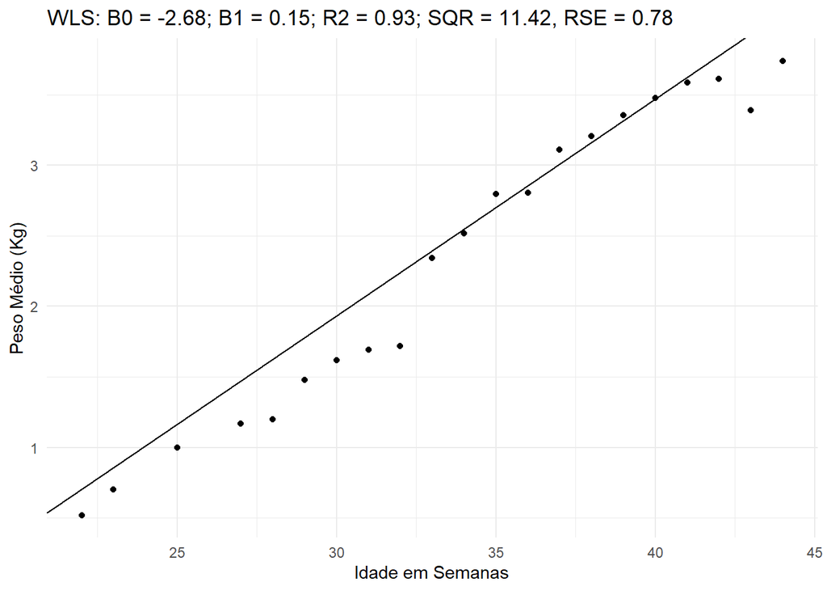

```r
ggplot(data = NULL) +
  geom_point(aes(x = x, y = y)) +
  geom_abline(intercept = beta0, slope = beta1) +
    xlab('Idade em Semanas') +
    ylab('Peso Médio (Kg)') +
    labs(title = 'WLS: B0 = -2.68; B1 = 0.15; R2 = 0.93; SQR = 11.42, RSE = 0.78') +
      theme_minimal()
```

#### 1.2.2 Erro Padrão (SE) dos Coeficientes

Por definição:

$$Var(\hat{\beta_0}) = \sigma^2(\frac{1}{\sum{w_i}} +
\frac{\overline{x}^2_w}{SSx})\text{; }
Var(\hat{\beta_1}) = \frac{\sigma^2}{SS_x}$$

Estimadores não viesados para $SE(\hat{\beta_0})$ e $SE(\hat{\beta_1})$

$$SE(\hat{\beta_0}) = \sqrt{s^2(\frac{1}{\sum{w_i}} + \frac{\overline{x}^2_w}{SS_x})} = s\sqrt{(\frac{1}{\sum{w_i}} + \frac{\overline{x}^2_w}{SS_x})}$$
$$SE(\hat{\beta_1}) = \sqrt{\frac{s^2}{SS_x}} = \frac{s}{\sqrt{SS_x}}$$

```r
se_b0 <- s * sqrt(1/sum(w) + media_ponderada_x^2/SSx)

se_b1 <- s / sqrt(SSx)

c('SE(B0)' = se_b0, 'SE(B1)' = se_b1)
```

```
##      SE(B0)      SE(B1)
## 0.371172341 0.009493212
```

#### 1.2.2 Erro Padrão (SE) das Previsões ($\hat{y}$)

Por definição:

$$Var(\hat{y_i}) = \sigma^2(\frac{1}{\sum{w_i}} + \frac{(x_i - \overline{x}_w)^2}
{SS_x})$$

Estimador não viesado para $Var(\hat{y_i})$

$$Var(\hat{y_i}) = s^2(\frac{1}{\sum{w_i}} + \frac{(x_i - \overline{x}_w)^2}
{SS_x})$$

```r
x_i <- 30

y_chapeu_i <- beta0 + beta1 * x_i

se_y_chapeu_i <- sqrt(s2 * (1/sum(w) + ((x_i - media_ponderada_x) ^ 2) / SSx))

c('X_i' = x_i, '^Y_i' = y_chapeu_i, 'SE(^Y_i)' = se_y_chapeu_i)
```

```
##       X_i      ^Y_i  SE(^Y_i)
## 30.000000  1.934392  0.088124
```

### 1.3 Teste de hipóteses sobre $\beta_j$

#### 1.3.1 Distribuição de $\beta_j$

$$\hat{\beta_j} \sim N(\beta_j, Var(\hat\beta_j))$$
$$Z = \frac{\hat{\beta_j} - \beta_j}{SE(\hat{\beta_j})} \sim N(0, 1)$$

Como $Var(\hat\beta_j)$ é estimada, então:

$$T = \frac{\hat{\beta_j} - \beta_j}{SE(\hat{\beta_j)}} \sim T_{df = n-p'}$$

Onde:

- $T$ = T-Student
- $p'$ = Número de coeficientes estimados
- $n$ = Número de Observações

#### 1.3.2 Teste

$$H0: \beta_j = 0$$
$$H1: \beta_j <>0$$

$$T_{obs} = \frac{\hat{\beta_j} - \beta_j^{Sob H0}(0)}{SE(\hat{\beta_j})}
\text{; df = n - p' = 21 - 2 = 19}$$

```r
t_obs_beta0 <- beta0 / se_b0
p_beta0 <- 2 * pt(abs(t_obs_beta0), df = 19, lower.tail = F)# P(T>t); * 2 (Bicaudal)

t_obs_beta1 <- beta1 / se_b1
p_beta1 <- 2 * pt(abs(t_obs_beta1), df = 19, lower.tail = F)# P(T>t); * 2 (Bicaudal)

c("T Obs Beta0" = t_obs_beta0, 'P-Valor B0' = p_beta0,
  "T Obs Beta1" = t_obs_beta1, 'P-Valor B1' = p_beta1)
```

```
##   T Obs Beta0    P-Valor B0   T Obs Beta1    P-Valor B1
## -7.216026e+00  7.485278e-07  1.619677e+01  1.416044e-12
```

### 1.4 Intervalos de Confiança

#### 1.4.1 Intervalo de Confiança para $\beta_j$

$$IC(\hat{\beta_j};1-\alpha) = \hat{\beta_j}\pm t_{df;\alpha/2}*SE(\hat{\beta_j})$$

```r
# Intervalo de 95%; t = 2.093
ic95_b0_sup <- beta0 + qt(0.975, df = 19) * se_b0
ic95_b0_inf <- beta0 - qt(0.975, df = 19) * se_b0

ic95_b1_sup <- beta1 + qt(0.975, df = 19) * se_b1
ic95_b1_inf <- beta1 - qt(0.975, df = 19) * se_b1

c("IC(95%;B0)Inf." = ic95_b0_inf, 'B0 Estimado' = beta0,
  'IC(95%;B0)Sup.' = ic95_b0_sup, "IC(95%;B1)Inf." = ic95_b1_inf,
  'B1 Estimado'= beta1, 'IC(95%;B1)Sup.' = ic95_b1_sup)
```

```
## IC(95%;B0)Inf.    B0 Estimado IC(95%;B0)Sup. IC(95%;B1)Inf.    B1 Estimado
##     -3.4552618     -2.6783891     -1.9015165      0.1338898      0.1537594
## IC(95%;B1)Sup.
##      0.1736289
```

## Regressão Linear Simples OLS

### 2.1 Dados

```r
data(gestation)

gestation %>%
  head() %>%
    kable() %>%
      kable_styling()
```

| Age | Births | Weight | SD |
| --- | --- | --- | --- |
| 22 | 1 | 0.520 | NA |
| 23 | 1 | 0.700 | NA |
| 25 | 1 | 1.000 | NA |
| 27 | 1 | 1.170 | NA |
| 28 | 6 | 1.198 | 0.121 |
| 29 | 1 | 1.480 | NA |

```r
describe(gestation) %>%
  round(2) %>%
    kable() %>%
      kable_styling()
```

|  | vars | n | mean | sd | median | trimmed | mad | min | max | range | skew | kurtosis | se |
| --- | --- | --- | --- | --- | --- | --- | --- | --- | --- | --- | --- | --- | --- |
| Age | 1 | 21 | 33.76 | 6.59 | 34.00 | 33.94 | 7.41 | 22.00 | 44.00 | 22.00 | -0.15 | -1.22 | 1.44 |
| Births | 2 | 21 | 72.05 | 123.59 | 7.00 | 44.53 | 8.90 | 1.00 | 401.00 | 400.00 | 1.57 | 1.01 | 26.97 |
| Weight | 3 | 21 | 2.33 | 1.07 | 2.52 | 2.38 | 1.33 | 0.52 | 3.74 | 3.22 | -0.21 | -1.55 | 0.23 |
| SD | 4 | 15 | 0.41 | 0.11 | 0.43 | 0.41 | 0.03 | 0.12 | 0.59 | 0.47 | -0.68 | 0.86 | 0.03 |

### 2.2 Estimação (Na Raça)

#### 2.2.1 Coeficientes ($\beta$’s), $Var(Y_i / X_i = x)$ e $R^2$

$$\hat{\beta_0} = \overline{y} - \hat{\beta_1} \overline{x}$$

$$\hat{\beta_1} = \frac{SS_{xy}}{SS_{x}} = \frac{\sum_{i=1}^{n}(x_i -
\overline{x})y_i}{\sum_{i=1}^{n}(x_i -
\overline{x})x_i}$$

$$R^2 = 1 - \frac{SQR}{SQT} = 1 - \frac{\sum_{i=1}^{n}(y_i - \hat{y})^2}{\sum_{i=1}^{n}(y_i - \overline{y})^2}$$

Por definição:

$$\sigma^2_{\epsilon} = Var(\epsilon) = E[(y_i - \overline{y_i})^2]$$

Estimador não viesado para $\sigma^2_{\epsilon}$

$$s^2 = EQM =\frac{SQR}{df} = \frac{\sum_{i=1}^{n}(y_i - \hat{y}_i)^2}{n-2}$$

Onde:

- $\overline{x} = \frac{\sum_{i=1}^{n}x_i}{n}$ (Média de X)
- $\overline{y} = \frac{\sum_{i=1}^{n}y_i}{n}$ (Média de Y)
- $\hat{y}_i = \hat{\beta_0} + \hat{\beta_1}x_i$ ($y$ ajustado)
- $df = n - 2$ (Graus de Liberdade)
- $s^2 = \text{EQM = Erro Quadrático Médio (MSE Mean Square Error)}$
- $s = \sqrt{s^2} =$ Erro Padrão dos Resíduos (RSE Residual Standard Error)
- $\epsilon$ é o termo aleatório (erro), tal que $\epsilon \sim N(0, \sigma^2_{\epsilon})$
- SQR = Soma dos Quadrados dos Resíduos (RSS)
- SQT = Soma dos Quadrados Totais (TSS)
- $R^2$ = Coeficiente de Determinação.

```r
x <- gestation$Age # Variável Independente
y <- gestation$Weight # Variável Dependente (Resposta)


media_x <- mean(x)
media_y <- mean(y)

SSxy <- sum((x - media_x) * y)
SSx <- sum((x - media_x) * x) # Soma dos Quadrados de X (Sum of Squares [SS])

beta1 <- SSxy / SSx

beta0 <- media_y - beta1 * media_x

SQR <- sum((y - (beta0 + beta1 * x)) ^ 2) # Soma dos Quadrados dos Resíduos (RSS)

df <- length(y) - 2 # n - 2

s2 <- SQR / df
s <- sqrt(s2) # RSE

r2 <- 1 - SQR / sum((y - media_y) ^ 2)

c('Beta0' = beta0, 'Beta1' = beta1, 'R2' = r2,'SQR' = SQR,
  'Erro Padrão dos Resíduos (RSE)' = s)
```

```
##                          Beta0                          Beta1
##                     -3.0498794                      0.1594830
##                             R2                            SQR
##                      0.9668240                      0.7591542
## Erro Padrão dos Resíduos (RSE)
##                      0.1998887
```

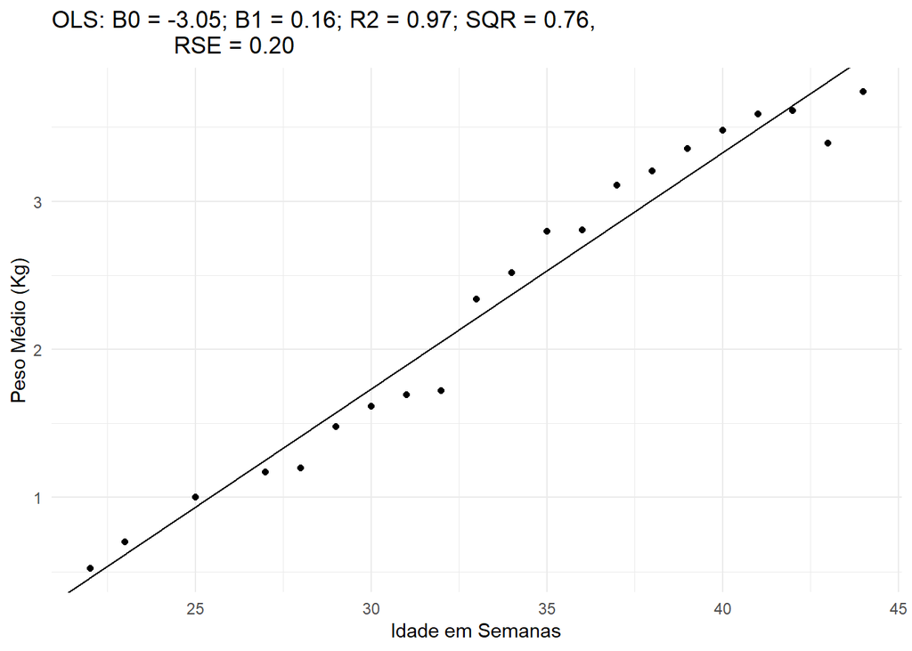

```r
ggplot(data = NULL) +
  geom_point(aes(x = x, y = y)) +
  geom_abline(intercept = beta0, slope = beta1) +
    xlab('Idade em Semanas') +
    ylab('Peso Médio (Kg)') +
    labs(title = 'OLS: B0 = -3.05; B1 = 0.16; R2 = 0.97; SQR = 0.76,
                  RSE = 0.20') +
      theme_minimal()
```

#### 2.2.2 Erro Padrão (SE) dos Coeficientes

Por definição:

$$Var(\hat{\beta_0}) = \sigma^2(\frac{1}{n} +
\frac{\overline{x}^2}{SSx})\text{; }
Var(\hat{\beta_1}) = \frac{\sigma^2}{SS_x}$$

Estimadores não viesados para $SE(\hat{\beta_0})$ e $SE(\hat{\beta_1})$

$$SE(\hat{\beta_0}) = \sqrt{s^2(\frac{1}{n} + \frac{\overline{x}^2}{SS_x})} = s\sqrt{(\frac{1}{n} + \frac{\overline{x}^2}{SS_x})}$$
$$SE(\hat{\beta_1}) = \sqrt{\frac{s^2}{SS_x}} = \frac{s}{\sqrt{SS_x}}$$

```r
n <- length(y)

se_b0 <- s * sqrt(1/n + media_x^2/SSx)

se_b1 <- s / sqrt(SSx)

c('SE(B0)' = se_b0, 'SE(B1)' = se_b1)
```

```
##      SE(B0)      SE(B1)
## 0.232945109 0.006777603
```

#### 2.2.2 Erro Padrão (SE) das Previsões ($\hat{y}$)

Por definição:

$$Var(\hat{y_i}) = \sigma^2(\frac{1}{n} + \frac{(x_i - \overline{x})^2}
{SS_x})$$

Estimador não viesado para $Var(\hat{y_i})$

$$Var(\hat{y_i}) = s^2(\frac{1}{n} + \frac{(x_i - \overline{x})^2}
{SS_x})$$

```r
x_i <- 30

y_chapeu_i <- beta0 + beta1 * x_i

se_y_chapeu_i <- sqrt(s2 * (1/n + ((x_i - media_x) ^ 2) / SSx))

c('X_i' = x_i, '^Y_i' = y_chapeu_i, 'SE(^Y_i)' = se_y_chapeu_i)
```

```
##         X_i        ^Y_i    SE(^Y_i)
## 30.00000000  1.73461146  0.05052449
```

### 2.3 Teste de hipóteses sobre $\beta_j$

#### 2.3.1 Distribuição de $\beta_j$

$$\hat{\beta_j} \sim N(\beta_j, Var(\hat\beta_j))$$
$$Z = \frac{\hat{\beta_j} - \beta_j}{SE(\hat{\beta_j})}$$

Como $Var(\hat\beta_j)$ é estimada, então:

$$T = \frac{\hat{\beta_j} - \beta_j}{SE(\hat{\beta_j)}} \sim T_{df = n-p'}$$

Onde:

- $T$ = T-Student
- $p'$ = Número de coeficientes estimados
- $n$ = Número de Observações
- $df$ = Graus de liberdade

#### 2.3.2 Teste

$$H0: \beta_j = 0$$
$$H1: \beta_j <>0$$

$$T_{obs} = \frac{\hat{\beta_j} - \beta_j^{Sob H0}(0)}{SE(\hat{\beta_j})}
\text{; df = n - p' = 21 - 2 = 19}$$

```r
t_obs_beta0 <- beta0 / se_b0
p_beta0 <- 2 * pt(abs(t_obs_beta0), df = 19, lower.tail = F)# P(T>t); * 2 (Bicaudal)

t_obs_beta1 <- beta1 / se_b1
p_beta1 <- 2 * pt(abs(t_obs_beta1), df = 19, lower.tail = F)# P(T>t); * 2 (Bicaudal)

c("T Obs Beta0" = t_obs_beta0, 'P-Valor B0' = p_beta0,
  "T Obs Beta1" = t_obs_beta1, 'P-Valor B1' = p_beta1)
```

```
##   T Obs Beta0    P-Valor B0   T Obs Beta1    P-Valor B1
## -1.309270e+01  5.865837e-11  2.353089e+01  1.626678e-15
```

### 2.4 Intervalos de Confiança

#### 2.4.1 Intervalo de Confiança para $\beta_j$

$$IC(\hat{\beta_j};1-\alpha)=\hat{\beta_j}\pm t_{df;\alpha/2}*SE(\hat{\beta_j})$$

```r
# Intervalo de 95%; t = 2.093
ic95_b0_sup <- beta0 + qt(0.975, df = 19) * se_b0
ic95_b0_inf <- beta0 - qt(0.975, df = 19) * se_b0

ic95_b1_sup <- beta1 + qt(0.975, df = 19) * se_b1
ic95_b1_inf <- beta1 - qt(0.975, df = 19) * se_b1

c("IC(95%;B0)Inf." = ic95_b0_inf, 'B0 Estimado' = beta0,
  'IC(95%;B0)Sup.' = ic95_b0_sup, "IC(95%;B1)Inf." = ic95_b1_inf,
  'B1 Estimado'= beta1, 'IC(95%;B1)Sup.' = ic95_b1_sup)
```

```
## IC(95%;B0)Inf.    B0 Estimado IC(95%;B0)Sup. IC(95%;B1)Inf.    B1 Estimado
##     -3.5374391     -3.0498794     -2.5623197      0.1452973      0.1594830
## IC(95%;B1)Sup.
##      0.1736687
```

## Regressão Linear Múltipla

### 3.1 Dados

```r
data("lungcap")

lungcap$Smoke <- factor(lungcap$Smoke)

lungcap %>%
  head() %>%
    kable() %>%
      kable_styling()
```

| Age | FEV | Ht | Gender | Smoke |
| --- | --- | --- | --- | --- |
| 3 | 1.072 | 46 | F | 0 |
| 4 | 0.839 | 48 | F | 0 |
| 4 | 1.102 | 48 | F | 0 |
| 4 | 1.389 | 48 | F | 0 |
| 4 | 1.577 | 49 | F | 0 |
| 4 | 1.418 | 49 | F | 0 |

```r
summary(lungcap)
```

```
##       Age              FEV              Ht        Gender  Smoke
##  Min.   : 3.000   Min.   :0.791   Min.   :46.00   F:318   0:589
##  1st Qu.: 8.000   1st Qu.:1.981   1st Qu.:57.00   M:336   1: 65
##  Median :10.000   Median :2.547   Median :61.50
##  Mean   : 9.931   Mean   :2.637   Mean   :61.14
##  3rd Qu.:12.000   3rd Qu.:3.119   3rd Qu.:65.50
##  Max.   :19.000   Max.   :5.793   Max.   :74.00
```

### 3.2 Estimação - Matricial (Na Raça)

#### 3.2.1 Modelo

$$\mathbf{\hat{Y}} = \mathbf{X}\mathbf{\beta} + \mathbf\epsilon=\hat{\beta_0} + \sum_{j=1}^{p}\hat{\beta_j}\mathbf{X}_{ji}$$

$$\begin{bmatrix}
\hat{y_1}\\
\vdots\\
\vdots\\
\hat{y_n}\\
\end{bmatrix}_{nx1} = \begin{bmatrix}
1 & x_{11} & x_{21}& \dots & x_{j1}\\
1 & x_{12}& x_{22} & \dots & x_{j2}\\
\vdots & \vdots & \vdots & \dots & \vdots \\
1 & x_{1n} & x_{2n}& \dots & x_{jn}\\
\end{bmatrix}_{nx(j+1)} \begin{bmatrix}
\hat{\beta_0}\\
\hat{\beta_1}\\
\vdots\\
\hat{\beta_j}\\
\end{bmatrix}_{(j+1)x1}$$
$$Var(Y) = \sigma^2 I_{n}= \begin{bmatrix}
\sigma^2 & 0 & \dots & 0\\
0 & \sigma^2 & \ddots & \vdots\\
\vdots & \ddots & \ddots & 0 \\
0 & \dots & 0 & \sigma^2\\
\end{bmatrix}_{nXn}$$

#### 3.2.2 Estimativa dos coeficientes *$\mathbf{\beta}$*

$$\mathbf{\beta}_{px1} = (\mathbf{X^T}_{pxn}\mathbf{X}_{nxp})_{pxp}^{-1}\mathbf{X^T}_{pxn}
\mathbf{Y}_{nx1}$$
Onde:

- $\mathbf{X}_{nxp}$ é a matriz das p-1 variáveis preditoras e mais uma primeira coluna com 1 representando o intercepto.
- $\mathbf{X^T}_{pxn}$ é a transposta de X
- $^(\mathbf{X^T}\mathbf{X})^{-1}$ é a inversa do produto.
- $\mathbf{Y}_{nx1}$ é a matriz (vetor) da variável resposta.
- n = Número de observações
- p = Número de coeficientes estimados (Intercepto mais variáveis)

```r
# Matriz das Preditoras (1@ coluna é 1 pelo intercepto)
X <- model.matrix( ~ Age + Ht + factor(Gender) + factor(Smoke), data = lungcap)
# Fatores são convertidos para 1 (Masculino / Fumante) ou 0 (Fem / N_Fumante)
Y <- log(lungcap$FEV)

betas <- solve(t(X) %*% X) %*%  t(X) %*% Y
# Ou ainda
# betas <- solve((t(X) %*% X), (t(X) %*% Y))
# betas <- qr.coef(qr(X), Y)

betas
```

```
##                        [,1]
## (Intercept)     -1.94399818
## Age              0.02338721
## Ht               0.04279579
## factor(Gender)M  0.02931936
## factor(Smoke)1  -0.04606754
```

#### 3.2.2 Estimativa da variância *$\sigma^2_{\epsilon}$*

$$s^2 = \frac{(\mathbf{Y} - \mathbf{\hat{Y}})^T(\mathbf{Y} - \mathbf{\hat{Y}})}
{n - p}$$
Onde:

- $\mathbf{Y}_{nx1}$ é a matriz (vetor) da variável resposta.
- $\mathbf{\hat{Y}}_{nx1} = \mathbf{X}\mathbf{\beta}$ é a matriz (vetor) dos valores ajustados da variável resposta
- n = Número de observações
- p = Número de coeficientes estimados (Intercepto mais variáveis)

```r
n <- length(Y)
p <- length(betas)

s2 <- t(Y - (X %*% betas)) %*% (Y - (X %*% betas)) / (n - p)

s <- sqrt(s2)

c('Variância' = s2,
  'RSE' = s) # Residual Standard Error
```

```
##  Variância        RSE
## 0.02116111 0.14546857
```

#### 3.2.3 Estimativa da variância dos coeficientes *$\sigma^2_{\beta_{j}}$*

Por definição:

$$Var(\hat{\beta}) = \sigma^2_{\epsilon} (\mathbf{X}^T\mathbf{X})^{-1}$$

Estimador não viesado para $Var(\hat{\beta})$

$$Var(\hat{\beta}) =s^2(\mathbf{X}^T\mathbf{X})^{-1}$$

- Onde $Var(\hat{\beta_j})$ é encontrada na diagonal principal da matriz

```r
matriz_var_betas <- c(s2) * solve(t(X) %*% X)

var_betas <- diag(matriz_var_betas)
se_betas <- diag(matriz_var_betas)


sumario <- rbind(var_betas, se_betas)
rownames(sumario) <- c("Var Beta", "SE Beta")
sumario
```

[output not shown]

#### 3.2.4 Estimativa da variância dos valores ajustados *$\sigma^2_{\hat{y_i}}$*

Por definição:
$$Var(\hat{y}_i) = \mathbf{x}_i(\mathbf{X}^T \mathbf{X})^{-1}\mathbf{x}_i^{T}\sigma^2_\epsilon$$
Estimador não viesado:
$$Var(\hat{y}_i) = \mathbf{x}_i(\mathbf{X}^T \mathbf{X})^{-1}\mathbf{x}_i^{T}s^2$$

Onde:

Por definição: * $\mathbf{x}_i$ corresponde ao *vetor* da i-ésima linha da matriz de covariáveis $\mathbf{X}$ tendo dimensões 1xp

```r
x_i <- matrix(c(1, 18, 66, 0, 1), nr = 1)# = Intercepto, Age, Ht, Gender, Smoke -> Vetor Linha

y_chapeu_i <- x_i %*% betas
var_y_chapeu_i <- x_i %*% solve(t(X) %*% X) %*% t(x_i) * s2


sumario <- cbind(y_chapeu_i, var_y_chapeu_i, sqrt(var_y_chapeu_i))
colnames(sumario) <- c("^Y", "Var(^Y)", "SE(^Y)")
sumario
```

```
##            ^Y      Var(^Y)     SE(^Y)
## [1,] 1.255426 0.0005525527 0.02350644
```

### ANOVA para um Modelo de Regressão Linear

#### 4.1 Teoria

Trata-se de um teste para avaliar as seguintes hipóteses:

$H_0: \beta_j$ = 0, para todo *j*

$H_1: \beta_j \neq$ 0, para algum *j*

Seja:

$$F = \frac{\frac{SS_{Reg}}{p-1}}{\frac{SS_{Error}}{n-p}}=
\frac{MS_{Reg}}{MSE}$$

Então:

$$F \sim F(df_1, df_2)\sim F(p-1, n-p)$$

Onde:

- $SS_{Reg} = \sum_{i=1}^{n} (\hat{y}_i - \overline{y})^2$ = Sum of Squares of Regression
- $SS_{Error} = \sum_{i=1}^{n} ({y}_i - \hat{y}_i)^2$ = Sum of Squares of Errors
- $df_1 = p -1$ = Graus de Liberdade do Numerador
- $df_2 = n - p$ = Graus de Liberdade do Denominador
- $MSE = \sigma^2_\epsilon$ = Mean Square Error
- $MS_{Reg}$ = Mean Square of Regression
- p = Número de Coeficientes estimados
- n = Número de observações

```r
data("gestation") # Dados da Regrassão Linear Simples em 2.1


x <- gestation$Age # Variável Independente
y <- gestation$Weight # Variável Dependente (Resposta)

media_x <- mean(x)
media_y <- mean(y)

SSxy <- sum((x - media_x) * y)
SSx <- sum((x - media_x) * x) # Soma dos Quadrados de X (Sum of Squares [SS])

beta1 <- SSxy / SSx
beta0 <- media_y - beta1 * media_x

y_ajustado <- beta0 + beta1 * x

c('Beta0' = beta0, 'Beta1' = beta1)
```

```
##     Beta0     Beta1
## -3.049879  0.159483
```

```r
# Tabela Anova
SSReg <- sum((y_ajustado - media_y) ^ 2)
df1 <- 2 - 1 # p - 1 -> 2 coeficientes: p = 2

SSError <- sum((y - y_ajustado) ^ 2)
df2 <- length(y) - 2 # n - p

MSE <- SSError / df2
MSReg <- SSReg / df1

F_Obs <- MSReg / MSE

p_valor <- pf(F_Obs, df1, df2, lower.tail = F)# P(F > x)


data.frame("DF" = c(df1, df2),
           "Soma Quadrados" = c(SSReg, SSError),
           "Media SQ" = c(MSReg, MSE),
           "F Calc" = c(F_Obs, NA),
           "P-Valor" = c(p_valor, NA),
           "Decisão" = c(ifelse(p_valor < 0.05, "Rejeita HO",
                                                "Não Rejeita H0"), NA))
```

```
##   DF Soma.Quadrados    Media.SQ   F.Calc      P.Valor    Decisão
## 1  1     22.1234629 22.12346294 553.7028 1.626678e-15 Rejeita HO
## 2 19      0.7591542  0.03995548       NA           NA       <NA>
```

#### 4.2 Função no R

```r
modelo_linear_simples <- lm(Weight ~ Age, data = gestation)

anova(modelo_linear_simples)
```

```
## Analysis of Variance Table
##
## Response: Weight
##           Df  Sum Sq Mean Sq F value    Pr(>F)
## Age        1 22.1235  22.123   553.7 1.627e-15 ***
## Residuals 19  0.7592   0.040
## ---
## Signif. codes:  0 '***' 0.001 '**' 0.01 '*' 0.05 '.' 0.1 ' ' 1
```

### 5. ANOVA para comparar Modelos de Regressão Linear Aninhados

#### 5.1 Teoria

Sejam:

Modelo A: $\hat{y} = \hat{\beta_0} + \hat{\beta_1}x_1 + ...+ \hat{\beta}_{pA}x_{pA}$

Modelo B:$\hat{y} = \hat{\beta_0} + \hat{\beta_1}x_1 + ...+ \hat{\beta}_{pA}x_{pA} + ... + \hat{\beta}_{pB}x_{pB}$

O *Modelo A* está aninhado ao *B*, pois pode ser obtido em B ao fazer-se $\hat{\beta}_{pA+1} = ...= \hat{\beta}_{pB} = 0$.

Testamos as hipóteses:

$H_0: \hat{\beta}_{pA+1} = ...=\hat{\beta}_{pB} = 0$ (Modelos A e B são equivalentes)

$H_1: \hat{\beta}_j \neq 0$ para algum j, j = pA + 1, …, pB

Para tal, utilizamos a estatística F, diferença em RSS (Residual Sum of Squares).

$$F = \frac{\frac{RSS_A - RSS_B} {p_B-p_A}}{s^2_B} = \frac{\frac{RSS_A - RSS_B} {p_B-p_A}}{\frac{RSS_B}{n-p_B}}$$

$$F\sim F(p_B - p_A, n - p_B)$$

Onde:

- $RSS_A = {\sum_{i=1}^{n}(\hat{y}_i - y_i)^2}_A = {\sum_{i=1}^{n}e_i^2}_A$ (Soma dos Quadrados dos Resíduos do modelo A)
- $RSS_B = {\sum_{i=1}^{n}(\hat{y}_i - y_i)^2}_B = {\sum_{i=1}^{n}e_i^2}_B$ (Soma dos Quadrados dos Resíduos do modelo B)
- $p_B$ = Número de coeficientes do modelo B
- $p_A$ = Número de coeficientes do modelo A
- $n$ = Número de observações

```r
modelo_A <- lm(log(FEV) ~ Age + Smoke, data = lungcap)
modelo_B <- lm(log(FEV) ~ Age + Ht + Gender + Smoke, data = lungcap)

RSS_A <- sum(modelo_A$residuals ^ 2)
RSS_B <- sum(modelo_B$residuals ^ 2)

n <- length(lungcap$FEV)

p_A <- length(modelo_A$coefficients)
p_B <- length(modelo_B$coefficients)

F_Obs <- ((RSS_A - RSS_B) / (p_B - p_A)) / (RSS_B / (n - p_B))
# OU
# F_Obs <- ((RSS_A - RSS_B) / (p_B - p_A)) / (summary(modelo_B)$sigma ^ 2)

p_valor <- pf(F_Obs, df1 = p_B - p_A, df2 = n - p_B, lower.tail = F)


data.frame('RSS' = round(c(RSS_A, RSS_B), 3),
           'DF' = c(n - p_A, n - p_B),
           'DF Diff' = c(NA, p_B - p_A),
           'SS A-B' = round(c(NA, RSS_A - RSS_B), 3),
           'F Obs' = c(NA, F_Obs),
           'P-Valor' = c(NA, p_valor),
           'Decisão' = ifelse(p_valor < 0.05, "Rejeita H0", "Não Rejeita H0"),
           row.names = c('Modelo A (2 var)', 'Modelo B (4 var)'))
```

```
##                     RSS  DF DF.Diff SS.A.B    F.Obs       P.Valor    Decisão
## Modelo A (2 var) 28.920 651      NA     NA       NA            NA Rejeita H0
## Modelo B (4 var) 13.734 649       2 15.186 358.8249 1.128849e-105 Rejeita H0
```

#### 5.2 Função no R

```r
anova(modelo_A, modelo_B)
```

```
## Analysis of Variance Table
##
## Model 1: log(FEV) ~ Age + Smoke
## Model 2: log(FEV) ~ Age + Ht + Gender + Smoke
##   Res.Df    RSS Df Sum of Sq      F    Pr(>F)
## 1    651 28.920
## 2    649 13.734  2    15.186 358.82 < 2.2e-16 ***
## ---
## Signif. codes:  0 '***' 0.001 '**' 0.01 '*' 0.05 '.' 0.1 ' ' 1
```